# Risk Factor Analysis

## Outcome Variable

**Outcome Variable:** stunted

## Predictor Variables

**Intervention Variable:** feducyrs

**Adjustment Set:**

- arm
- W_mage
- meducyrs
- hhwealth_quart
- W_mhtcm
- W_gagebrth
- W_birthwt
- W_birthlen
- single
- delta_W_mage
- delta_meducyrs
- delta_hhwealth_quart
- delta_W_mhtcm
- delta_W_gagebrth
- delta_W_birthwt
- delta_W_birthlen
- delta_single

## Stratifying Variables

The analysis was stratified on these variable(s):

- agecat
- studyid
- country

## Data Summary

| agecat | studyid | country | feducyrs | stunted | n_cell | n |
| --- | --- | --- | --- | --- | --- | --- |
| Birth | ki0047075b-MAL-ED | BANGLADESH | High | 0 | 44 | 144 |
| Birth | ki0047075b-MAL-ED | BANGLADESH | High | 1 | 8 | 144 |
| Birth | ki0047075b-MAL-ED | BANGLADESH | Low | 0 | 30 | 144 |
| Birth | ki0047075b-MAL-ED | BANGLADESH | Low | 1 | 8 | 144 |
| Birth | ki0047075b-MAL-ED | BANGLADESH | Medium | 0 | 44 | 144 |
| Birth | ki0047075b-MAL-ED | BANGLADESH | Medium | 1 | 10 | 144 |
| Birth | ki0047075b-MAL-ED | INDIA | High | 0 | 32 | 123 |
| Birth | ki0047075b-MAL-ED | INDIA | High | 1 | 6 | 123 |
| Birth | ki0047075b-MAL-ED | INDIA | Low | 0 | 46 | 123 |
| Birth | ki0047075b-MAL-ED | INDIA | Low | 1 | 4 | 123 |
| Birth | ki0047075b-MAL-ED | INDIA | Medium | 0 | 30 | 123 |
| Birth | ki0047075b-MAL-ED | INDIA | Medium | 1 | 5 | 123 |
| Birth | ki0047075b-MAL-ED | NEPAL | High | 0 | 26 | 67 |
| Birth | ki0047075b-MAL-ED | NEPAL | High | 1 | 1 | 67 |
| Birth | ki0047075b-MAL-ED | NEPAL | Low | 0 | 17 | 67 |
| Birth | ki0047075b-MAL-ED | NEPAL | Low | 1 | 2 | 67 |
| Birth | ki0047075b-MAL-ED | NEPAL | Medium | 0 | 16 | 67 |
| Birth | ki0047075b-MAL-ED | NEPAL | Medium | 1 | 5 | 67 |
| Birth | ki0047075b-MAL-ED | PERU | High | 0 | 106 | 236 |
| Birth | ki0047075b-MAL-ED | PERU | High | 1 | 10 | 236 |
| Birth | ki0047075b-MAL-ED | PERU | Low | 0 | 52 | 236 |
| Birth | ki0047075b-MAL-ED | PERU | Low | 1 | 13 | 236 |
| Birth | ki0047075b-MAL-ED | PERU | Medium | 0 | 52 | 236 |
| Birth | ki0047075b-MAL-ED | PERU | Medium | 1 | 3 | 236 |
| Birth | ki0047075b-MAL-ED | SOUTH AFRICA | High | 0 | 30 | 91 |
| Birth | ki0047075b-MAL-ED | SOUTH AFRICA | High | 1 | 5 | 91 |
| Birth | ki0047075b-MAL-ED | SOUTH AFRICA | Low | 0 | 30 | 91 |
| Birth | ki0047075b-MAL-ED | SOUTH AFRICA | Low | 1 | 0 | 91 |
| Birth | ki0047075b-MAL-ED | SOUTH AFRICA | Medium | 0 | 23 | 91 |
| Birth | ki0047075b-MAL-ED | SOUTH AFRICA | Medium | 1 | 3 | 91 |

[output cut: 288 more lines]

The following strata were considered:

- agecat: 24 months, studyid: ki0047075b-MAL-ED, country: BANGLADESH
- agecat: 24 months, studyid: ki0047075b-MAL-ED, country: INDIA
- agecat: 24 months, studyid: ki0047075b-MAL-ED, country: NEPAL
- agecat: 24 months, studyid: ki0047075b-MAL-ED, country: PERU
- agecat: 24 months, studyid: ki0047075b-MAL-ED, country: SOUTH AFRICA
- agecat: 24 months, studyid: ki0047075b-MAL-ED, country: TANZANIA, UNITED REPUBLIC OF
- agecat: 24 months, studyid: ki1017093b-PROVIDE, country: BANGLADESH
- agecat: 24 months, studyid: ki1017093c-NIH-Crypto, country: BANGLADESH
- agecat: 24 months, studyid: ki1066203-TanzaniaChild2, country: TANZANIA, UNITED REPUBLIC OF
- agecat: 24 months, studyid: ki1113344-GMS-Nepal, country: NEPAL
- agecat: 24 months, studyid: ki1119695-PROBIT, country: BELARUS
- agecat: 24 months, studyid: ki1126311-ZVITAMBO, country: ZIMBABWE
- agecat: 24 months, studyid: ki1135781-COHORTS, country: GUATEMALA
- agecat: 24 months, studyid: ki1135781-COHORTS, country: INDIA
- agecat: 24 months, studyid: ki1135781-COHORTS, country: PHILIPPINES
- agecat: 24 months, studyid: ki1148112-LCNI-5, country: MALAWI
- agecat: 24 months, studyid: kiGH5241-JiVitA-3, country: BANGLADESH
- agecat: 24 months, studyid: kiGH5241-JiVitA-4, country: BANGLADESH
- agecat: 6 months, studyid: ki0047075b-MAL-ED, country: BANGLADESH
- agecat: 6 months, studyid: ki0047075b-MAL-ED, country: INDIA
- agecat: 6 months, studyid: ki0047075b-MAL-ED, country: NEPAL
- agecat: 6 months, studyid: ki0047075b-MAL-ED, country: PERU
- agecat: 6 months, studyid: ki0047075b-MAL-ED, country: SOUTH AFRICA
- agecat: 6 months, studyid: ki0047075b-MAL-ED, country: TANZANIA, UNITED REPUBLIC OF
- agecat: 6 months, studyid: ki1000304b-SAS-CompFeed, country: INDIA
- agecat: 6 months, studyid: ki1000304b-SAS-FoodSuppl, country: INDIA
- agecat: 6 months, studyid: ki1017093b-PROVIDE, country: BANGLADESH
- agecat: 6 months, studyid: ki1017093c-NIH-Crypto, country: BANGLADESH
- agecat: 6 months, studyid: ki1066203-TanzaniaChild2, country: TANZANIA, UNITED REPUBLIC OF
- agecat: 6 months, studyid: ki1113344-GMS-Nepal, country: NEPAL
- agecat: 6 months, studyid: ki1119695-PROBIT, country: BELARUS
- agecat: 6 months, studyid: ki1126311-ZVITAMBO, country: ZIMBABWE
- agecat: 6 months, studyid: ki1135781-COHORTS, country: GUATEMALA
- agecat: 6 months, studyid: ki1135781-COHORTS, country: INDIA
- agecat: 6 months, studyid: ki1135781-COHORTS, country: PHILIPPINES
- agecat: 6 months, studyid: ki1148112-LCNI-5, country: MALAWI
- agecat: 6 months, studyid: kiGH5241-JiVitA-3, country: BANGLADESH
- agecat: 6 months, studyid: kiGH5241-JiVitA-4, country: BANGLADESH
- agecat: Birth, studyid: ki0047075b-MAL-ED, country: BANGLADESH
- agecat: Birth, studyid: ki0047075b-MAL-ED, country: INDIA
- agecat: Birth, studyid: ki0047075b-MAL-ED, country: NEPAL
- agecat: Birth, studyid: ki0047075b-MAL-ED, country: PERU
- agecat: Birth, studyid: ki0047075b-MAL-ED, country: SOUTH AFRICA
- agecat: Birth, studyid: ki0047075b-MAL-ED, country: TANZANIA, UNITED REPUBLIC OF
- agecat: Birth, studyid: ki1000304b-SAS-CompFeed, country: INDIA
- agecat: Birth, studyid: ki1017093c-NIH-Crypto, country: BANGLADESH
- agecat: Birth, studyid: ki1119695-PROBIT, country: BELARUS
- agecat: Birth, studyid: ki1126311-ZVITAMBO, country: ZIMBABWE
- agecat: Birth, studyid: ki1135781-COHORTS, country: GUATEMALA
- agecat: Birth, studyid: ki1135781-COHORTS, country: INDIA
- agecat: Birth, studyid: ki1135781-COHORTS, country: PHILIPPINES
- agecat: Birth, studyid: kiGH5241-JiVitA-3, country: BANGLADESH
- agecat: Birth, studyid: kiGH5241-JiVitA-4, country: BANGLADESH

### Dropped Strata

Some strata were dropped due to rare outcomes:

- agecat: Birth, studyid: ki0047075b-MAL-ED, country: INDIA
- agecat: Birth, studyid: ki0047075b-MAL-ED, country: NEPAL
- agecat: Birth, studyid: ki0047075b-MAL-ED, country: PERU
- agecat: Birth, studyid: ki0047075b-MAL-ED, country: SOUTH AFRICA
- agecat: Birth, studyid: ki0047075b-MAL-ED, country: TANZANIA, UNITED REPUBLIC OF
- agecat: Birth, studyid: ki1000304b-SAS-CompFeed, country: INDIA
- agecat: Birth, studyid: ki1017093c-NIH-Crypto, country: BANGLADESH
- agecat: Birth, studyid: ki1119695-PROBIT, country: BELARUS
- agecat: 6 months, studyid: ki0047075b-MAL-ED, country: NEPAL
- agecat: 6 months, studyid: ki0047075b-MAL-ED, country: SOUTH AFRICA
- agecat: 24 months, studyid: ki0047075b-MAL-ED, country: TANZANIA, UNITED REPUBLIC OF
- agecat: 24 months, studyid: ki1066203-TanzaniaChild2, country: TANZANIA, UNITED REPUBLIC OF

## Methods Detail

We’re interested in the causal parameters $E[Y_a]$ for all values of $a \in \mathcal{A}$. These parameters represent the mean outcome if, possibly contrary to fact, we intervened to set all units to have $A=a$. Under the randomization and positivity assumptions, these are identified by the statistical parameters $\psi_a=E_W[E_{Y|A,W}(Y|A=a,W)]$. In addition, we’re interested in the mean of $Y$, $E[Y]$ under no intervention (the observed mean). We will estimate these parameters by using SuperLearner to fit the relevant likelihood factors – $E_{Y|A,W}(Y|A=a,W)$ and $p(A=a|W)$, and then updating our likelihood fit using a joint TMLE.

For unadjusted analyses ($W=\{\}$), initial likelihoods were estimated using Lrnr_glm to estimate the simple $E(Y|A)$ and Lrnr_mean to estimate $p(A)$. For adjusted analyses, a small library containing Lrnr_glmnet, Lrnr_xgboost, and Lrnr_mean was used.

Having estimated these parameters, we will then use the delta method to estimate relative risks and attributable risks relative to a prespecified baseline level of $A$.

# Results Detail

## Results Plots

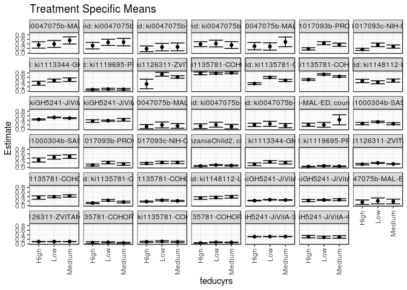

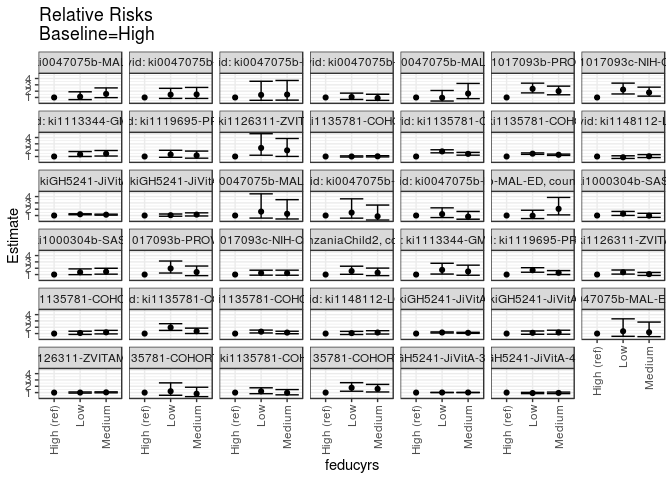

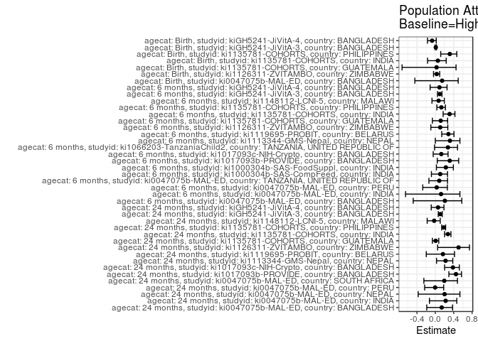

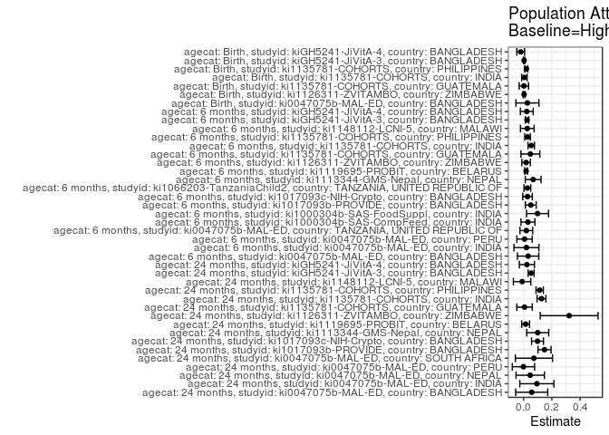

## Results Table

### Parameter: TSM

| agecat | studyid | country | intervention_level | baseline_level | estimate | ci_lower | ci_upper |
| --- | --- | --- | --- | --- | --- | --- | --- |
| Birth | ki0047075b-MAL-ED | BANGLADESH | High | NA | 0.1538462 | 0.0554388 | 0.2522535 |
| Birth | ki0047075b-MAL-ED | BANGLADESH | Low | NA | 0.2105263 | 0.0804520 | 0.3406006 |
| Birth | ki0047075b-MAL-ED | BANGLADESH | Medium | NA | 0.1851852 | 0.0812178 | 0.2891525 |
| Birth | ki1126311-ZVITAMBO | ZIMBABWE | High | NA | 0.0998245 | 0.0913108 | 0.1083383 |
| Birth | ki1126311-ZVITAMBO | ZIMBABWE | Low | NA | 0.1004377 | 0.0934888 | 0.1073865 |
| Birth | ki1126311-ZVITAMBO | ZIMBABWE | Medium | NA | 0.1033932 | 0.0981303 | 0.1086560 |
| Birth | ki1135781-COHORTS | GUATEMALA | High | NA | 0.0580645 | 0.0212246 | 0.0949044 |
| Birth | ki1135781-COHORTS | GUATEMALA | Low | NA | 0.0704225 | 0.0437906 | 0.0970545 |
| Birth | ki1135781-COHORTS | GUATEMALA | Medium | NA | 0.0476190 | 0.0232611 | 0.0719770 |
| Birth | ki1135781-COHORTS | INDIA | High | NA | 0.0899532 | 0.0657772 | 0.1141292 |
| Birth | ki1135781-COHORTS | INDIA | Low | NA | 0.1082913 | 0.0790222 | 0.1375603 |
| Birth | ki1135781-COHORTS | INDIA | Medium | NA | 0.0878767 | 0.0596433 | 0.1161100 |
| Birth | ki1135781-COHORTS | PHILIPPINES | High | NA | 0.0412761 | 0.0294003 | 0.0531520 |
| Birth | ki1135781-COHORTS | PHILIPPINES | Low | NA | 0.0730198 | 0.0551526 | 0.0908871 |
| Birth | ki1135781-COHORTS | PHILIPPINES | Medium | NA | 0.0655908 | 0.0501498 | 0.0810318 |
| Birth | kiGH5241-JiVitA-3 | BANGLADESH | High | NA | 0.3185288 | 0.3094601 | 0.3275976 |
| Birth | kiGH5241-JiVitA-3 | BANGLADESH | Low | NA | 0.3229582 | 0.3148373 | 0.3310792 |
| Birth | kiGH5241-JiVitA-3 | BANGLADESH | Medium | NA | 0.3236329 | 0.3149724 | 0.3322933 |
| Birth | kiGH5241-JiVitA-4 | BANGLADESH | High | NA | 0.3179035 | 0.2656145 | 0.3701924 |
| Birth | kiGH5241-JiVitA-4 | BANGLADESH | Low | NA | 0.2951826 | 0.2473553 | 0.3430099 |
| Birth | kiGH5241-JiVitA-4 | BANGLADESH | Medium | NA | 0.3023807 | 0.2482707 | 0.3564908 |
| 6 months | ki0047075b-MAL-ED | BANGLADESH | High | NA | 0.1200000 | 0.0295838 | 0.2104162 |
| 6 months | ki0047075b-MAL-ED | BANGLADESH | Low | NA | 0.1944444 | 0.0646687 | 0.3242202 |
| 6 months | ki0047075b-MAL-ED | BANGLADESH | Medium | NA | 0.1521739 | 0.0479796 | 0.2563682 |
| 6 months | ki0047075b-MAL-ED | INDIA | High | NA | 0.1395349 | 0.0355905 | 0.2434793 |
| 6 months | ki0047075b-MAL-ED | INDIA | Low | NA | 0.2037037 | 0.0958917 | 0.3115157 |
| 6 months | ki0047075b-MAL-ED | INDIA | Medium | NA | 0.1219512 | 0.0214230 | 0.2224794 |
| 6 months | ki0047075b-MAL-ED | PERU | High | NA | 0.1989832 | 0.1242898 | 0.2736765 |
| 6 months | ki0047075b-MAL-ED | PERU | Low | NA | 0.2436411 | 0.1324725 | 0.3548097 |
| 6 months | ki0047075b-MAL-ED | PERU | Medium | NA | 0.1648871 | 0.0709361 | 0.2588382 |

[output cut: 93 more lines]

### Parameter: E(Y)

| agecat | studyid | country | intervention_level | baseline_level | estimate | ci_lower | ci_upper |
| --- | --- | --- | --- | --- | --- | --- | --- |
| Birth | ki0047075b-MAL-ED | BANGLADESH | NA | NA | 0.1805556 | 0.1175113 | 0.2435998 |
| Birth | ki1126311-ZVITAMBO | ZIMBABWE | NA | NA | 0.1029718 | 0.0978372 | 0.1081063 |
| Birth | ki1135781-COHORTS | GUATEMALA | NA | NA | 0.0597015 | 0.0433139 | 0.0760891 |
| Birth | ki1135781-COHORTS | INDIA | NA | NA | 0.0952733 | 0.0796294 | 0.1109171 |
| Birth | ki1135781-COHORTS | PHILIPPINES | NA | NA | 0.0602158 | 0.0515157 | 0.0689159 |
| Birth | kiGH5241-JiVitA-3 | BANGLADESH | NA | NA | 0.3218470 | 0.3140700 | 0.3296240 |
| Birth | kiGH5241-JiVitA-4 | BANGLADESH | NA | NA | 0.2971175 | 0.2506806 | 0.3435544 |
| 6 months | ki0047075b-MAL-ED | BANGLADESH | NA | NA | 0.1515152 | 0.0901160 | 0.2129143 |
| 6 months | ki0047075b-MAL-ED | INDIA | NA | NA | 0.1594203 | 0.0981219 | 0.2207187 |
| 6 months | ki0047075b-MAL-ED | PERU | NA | NA | 0.2053571 | 0.1523375 | 0.2583768 |
| 6 months | ki0047075b-MAL-ED | TANZANIA, UNITED REPUBLIC OF | NA | NA | 0.2238806 | 0.1661102 | 0.2816510 |
| 6 months | ki1000304b-SAS-CompFeed | INDIA | NA | NA | 0.2835709 | 0.2656121 | 0.3015297 |
| 6 months | ki1000304b-SAS-FoodSuppl | INDIA | NA | NA | 0.4289474 | 0.3791199 | 0.4787748 |
| 6 months | ki1017093b-PROVIDE | BANGLADESH | NA | NA | 0.1612350 | 0.1313580 | 0.1911120 |
| 6 months | ki1017093c-NIH-Crypto | BANGLADESH | NA | NA | 0.2097902 | 0.1799252 | 0.2396552 |
| 6 months | ki1066203-TanzaniaChild2 | TANZANIA, UNITED REPUBLIC OF | NA | NA | 0.0966303 | 0.0837364 | 0.1095242 |
| 6 months | ki1113344-GMS-Nepal | NEPAL | NA | NA | 0.2117438 | 0.1779368 | 0.2455507 |
| 6 months | ki1119695-PROBIT | BELARUS | NA | NA | 0.0613372 | 0.0479409 | 0.0747335 |
| 6 months | ki1126311-ZVITAMBO | ZIMBABWE | NA | NA | 0.1645789 | 0.1564849 | 0.1726730 |
| 6 months | ki1135781-COHORTS | GUATEMALA | NA | NA | 0.4059735 | 0.3739435 | 0.4380034 |
| 6 months | ki1135781-COHORTS | INDIA | NA | NA | 0.1732852 | 0.1533446 | 0.1932258 |
| 6 months | ki1135781-COHORTS | PHILIPPINES | NA | NA | 0.2113885 | 0.1955816 | 0.2271953 |
| 6 months | ki1148112-LCNI-5 | MALAWI | NA | NA | 0.3633005 | 0.3301997 | 0.3964012 |
| 6 months | kiGH5241-JiVitA-3 | BANGLADESH | NA | NA | 0.2491941 | 0.2409375 | 0.2574508 |
| 6 months | kiGH5241-JiVitA-4 | BANGLADESH | NA | NA | 0.2494538 | 0.2301628 | 0.2687447 |
| 24 months | ki0047075b-MAL-ED | BANGLADESH | NA | NA | 0.4102564 | 0.3207450 | 0.4997678 |
| 24 months | ki0047075b-MAL-ED | INDIA | NA | NA | 0.4166667 | 0.3322428 | 0.5010905 |
| 24 months | ki0047075b-MAL-ED | NEPAL | NA | NA | 0.2307692 | 0.1437242 | 0.3178143 |
| 24 months | ki0047075b-MAL-ED | PERU | NA | NA | 0.3841463 | 0.3094772 | 0.4588155 |
| 24 months | ki0047075b-MAL-ED | SOUTH AFRICA | NA | NA | 0.3736264 | 0.2736811 | 0.4735717 |
| 24 months | ki1017093b-PROVIDE | BANGLADESH | NA | NA | 0.3292894 | 0.2909105 | 0.3676684 |
| 24 months | ki1017093c-NIH-Crypto | BANGLADESH | NA | NA | 0.2568093 | 0.2190047 | 0.2946140 |
| 24 months | ki1113344-GMS-Nepal | NEPAL | NA | NA | 0.4477912 | 0.4040733 | 0.4915091 |
| 24 months | ki1119695-PROBIT | BELARUS | NA | NA | 0.0845898 | 0.0544909 | 0.1146887 |
| 24 months | ki1126311-ZVITAMBO | ZIMBABWE | NA | NA | 0.6382488 | 0.5929899 | 0.6835078 |
| 24 months | ki1135781-COHORTS | GUATEMALA | NA | NA | 0.7879397 | 0.7625282 | 0.8133512 |
| 24 months | ki1135781-COHORTS | INDIA | NA | NA | 0.4608696 | 0.4345607 | 0.4871784 |
| 24 months | ki1135781-COHORTS | PHILIPPINES | NA | NA | 0.6214347 | 0.6016683 | 0.6412012 |
| 24 months | ki1148112-LCNI-5 | MALAWI | NA | NA | 0.4360771 | 0.3953670 | 0.4767872 |
| 24 months | kiGH5241-JiVitA-3 | BANGLADESH | NA | NA | 0.4886048 | 0.4753517 | 0.5018580 |
| 24 months | kiGH5241-JiVitA-4 | BANGLADESH | NA | NA | 0.3871566 | 0.3638029 | 0.4105104 |

### Parameter: RR

| agecat | studyid | country | intervention_level | baseline_level | estimate | ci_lower | ci_upper |
| --- | --- | --- | --- | --- | --- | --- | --- |
| Birth | ki0047075b-MAL-ED | BANGLADESH | High | High | 1.0000000 | 1.0000000 | 1.000000 |
| Birth | ki0047075b-MAL-ED | BANGLADESH | Low | High | 1.3684211 | 0.5623317 | 3.330021 |
| Birth | ki0047075b-MAL-ED | BANGLADESH | Medium | High | 1.2037037 | 0.5139229 | 2.819300 |
| Birth | ki1126311-ZVITAMBO | ZIMBABWE | High | High | 1.0000000 | 1.0000000 | 1.000000 |
| Birth | ki1126311-ZVITAMBO | ZIMBABWE | Low | High | 1.0061421 | 0.9220856 | 1.097861 |
| Birth | ki1126311-ZVITAMBO | ZIMBABWE | Medium | High | 1.0357490 | 0.9617278 | 1.115467 |
| Birth | ki1135781-COHORTS | GUATEMALA | High | High | 1.0000000 | 1.0000000 | 1.000000 |
| Birth | ki1135781-COHORTS | GUATEMALA | Low | High | 1.2128326 | 0.5794578 | 2.538516 |
| Birth | ki1135781-COHORTS | GUATEMALA | Medium | High | 0.8201058 | 0.3630178 | 1.852729 |
| Birth | ki1135781-COHORTS | INDIA | High | High | 1.0000000 | 1.0000000 | 1.000000 |
| Birth | ki1135781-COHORTS | INDIA | Low | High | 1.2038625 | 0.8229864 | 1.761007 |
| Birth | ki1135781-COHORTS | INDIA | Medium | High | 0.9769155 | 0.6437645 | 1.482474 |
| Birth | ki1135781-COHORTS | PHILIPPINES | High | High | 1.0000000 | 1.0000000 | 1.000000 |
| Birth | ki1135781-COHORTS | PHILIPPINES | Low | High | 1.7690561 | 1.2166770 | 2.572219 |
| Birth | ki1135781-COHORTS | PHILIPPINES | Medium | High | 1.5890726 | 1.0988328 | 2.298031 |
| Birth | kiGH5241-JiVitA-3 | BANGLADESH | High | High | 1.0000000 | 1.0000000 | 1.000000 |
| Birth | kiGH5241-JiVitA-3 | BANGLADESH | Low | High | 1.0139058 | 0.9935621 | 1.034666 |
| Birth | kiGH5241-JiVitA-3 | BANGLADESH | Medium | High | 1.0160237 | 0.9950146 | 1.037476 |
| Birth | kiGH5241-JiVitA-4 | BANGLADESH | High | High | 1.0000000 | 1.0000000 | 1.000000 |
| Birth | kiGH5241-JiVitA-4 | BANGLADESH | Low | High | 0.9285290 | 0.8336446 | 1.034213 |
| Birth | kiGH5241-JiVitA-4 | BANGLADESH | Medium | High | 0.9511715 | 0.8375717 | 1.080179 |
| 6 months | ki0047075b-MAL-ED | BANGLADESH | High | High | 1.0000000 | 1.0000000 | 1.000000 |
| 6 months | ki0047075b-MAL-ED | BANGLADESH | Low | High | 1.6203704 | 0.5922036 | 4.433611 |
| 6 months | ki0047075b-MAL-ED | BANGLADESH | Medium | High | 1.2681159 | 0.4581439 | 3.510072 |
| 6 months | ki0047075b-MAL-ED | INDIA | High | High | 1.0000000 | 1.0000000 | 1.000000 |
| 6 months | ki0047075b-MAL-ED | INDIA | Low | High | 1.4598765 | 0.5854028 | 3.640638 |
| 6 months | ki0047075b-MAL-ED | INDIA | Medium | High | 0.8739837 | 0.2877246 | 2.654787 |
| 6 months | ki0047075b-MAL-ED | PERU | High | High | 1.0000000 | 1.0000000 | 1.000000 |
| 6 months | ki0047075b-MAL-ED | PERU | Low | High | 1.2244304 | 0.6768545 | 2.214996 |
| 6 months | ki0047075b-MAL-ED | PERU | Medium | High | 0.8286486 | 0.4181996 | 1.641940 |

[output cut: 93 more lines]

### Parameter: PAR

| agecat | studyid | country | intervention_level | baseline_level | estimate | ci_lower | ci_upper |
| --- | --- | --- | --- | --- | --- | --- | --- |
| Birth | ki0047075b-MAL-ED | BANGLADESH | High | NA | 0.0267094 | -0.0549275 | 0.1083463 |
| Birth | ki1126311-ZVITAMBO | ZIMBABWE | High | NA | 0.0031472 | -0.0037448 | 0.0100393 |
| Birth | ki1135781-COHORTS | GUATEMALA | High | NA | 0.0016370 | -0.0315661 | 0.0348400 |
| Birth | ki1135781-COHORTS | INDIA | High | NA | 0.0053201 | -0.0138278 | 0.0244680 |
| Birth | ki1135781-COHORTS | PHILIPPINES | High | NA | 0.0189397 | 0.0081005 | 0.0297788 |
| Birth | kiGH5241-JiVitA-3 | BANGLADESH | High | NA | 0.0033182 | -0.0016997 | 0.0083360 |
| Birth | kiGH5241-JiVitA-4 | BANGLADESH | High | NA | -0.0207860 | -0.0485302 | 0.0069583 |
| 6 months | ki0047075b-MAL-ED | BANGLADESH | High | NA | 0.0315152 | -0.0443248 | 0.1073551 |
| 6 months | ki0047075b-MAL-ED | INDIA | High | NA | 0.0198854 | -0.0685947 | 0.1083655 |
| 6 months | ki0047075b-MAL-ED | PERU | High | NA | 0.0063740 | -0.0479564 | 0.0607043 |
| 6 months | ki0047075b-MAL-ED | TANZANIA, UNITED REPUBLIC OF | High | NA | 0.0191562 | -0.0259257 | 0.0642381 |
| 6 months | ki1000304b-SAS-CompFeed | INDIA | High | NA | 0.0303962 | -0.0190224 | 0.0798148 |
| 6 months | ki1000304b-SAS-FoodSuppl | INDIA | High | NA | 0.0985759 | 0.0205938 | 0.1765580 |
| 6 months | ki1017093b-PROVIDE | BANGLADESH | High | NA | 0.0506139 | 0.0126054 | 0.0886223 |
| 6 months | ki1017093c-NIH-Crypto | BANGLADESH | High | NA | 0.0273463 | -0.0065698 | 0.0612625 |
| 6 months | ki1066203-TanzaniaChild2 | TANZANIA, UNITED REPUBLIC OF | High | NA | 0.0265548 | 0.0025937 | 0.0505159 |
| 6 months | ki1113344-GMS-Nepal | NEPAL | High | NA | 0.0674599 | 0.0116710 | 0.1232488 |
| 6 months | ki1119695-PROBIT | BELARUS | High | NA | 0.0174946 | 0.0080274 | 0.0269619 |
| 6 months | ki1126311-ZVITAMBO | ZIMBABWE | High | NA | 0.0174318 | -0.0127145 | 0.0475781 |
| 6 months | ki1135781-COHORTS | GUATEMALA | High | NA | 0.0477660 | -0.0188250 | 0.1143569 |
| 6 months | ki1135781-COHORTS | INDIA | High | NA | 0.0537654 | 0.0310012 | 0.0765296 |
| 6 months | ki1135781-COHORTS | PHILIPPINES | High | NA | 0.0278259 | 0.0081814 | 0.0474704 |
| 6 months | ki1148112-LCNI-5 | MALAWI | High | NA | 0.0258367 | -0.0226080 | 0.0742814 |
| 6 months | kiGH5241-JiVitA-3 | BANGLADESH | High | NA | 0.0242988 | 0.0122034 | 0.0363941 |
| 6 months | kiGH5241-JiVitA-4 | BANGLADESH | High | NA | 0.0223656 | -0.0231434 | 0.0678745 |
| 24 months | ki0047075b-MAL-ED | BANGLADESH | High | NA | 0.0570230 | -0.0565666 | 0.1706127 |
| 24 months | ki0047075b-MAL-ED | INDIA | High | NA | 0.0936624 | -0.0270753 | 0.2144001 |
| 24 months | ki0047075b-MAL-ED | NEPAL | High | NA | 0.0465587 | -0.0539837 | 0.1471012 |
| 24 months | ki0047075b-MAL-ED | PERU | High | NA | -0.0015215 | -0.0805095 | 0.0774665 |
| 24 months | ki0047075b-MAL-ED | SOUTH AFRICA | High | NA | 0.0729346 | -0.0587252 | 0.2045944 |
| 24 months | ki1017093b-PROVIDE | BANGLADESH | High | NA | 0.1478651 | 0.1016217 | 0.1941086 |
| 24 months | ki1017093c-NIH-Crypto | BANGLADESH | High | NA | 0.0982992 | 0.0560638 | 0.1405345 |
| 24 months | ki1113344-GMS-Nepal | NEPAL | High | NA | 0.0997085 | 0.0215987 | 0.1778184 |
| 24 months | ki1119695-PROBIT | BELARUS | High | NA | 0.0139843 | -0.0137138 | 0.0416825 |
| 24 months | ki1126311-ZVITAMBO | ZIMBABWE | High | NA | 0.3224594 | 0.1175197 | 0.5273990 |
| 24 months | ki1135781-COHORTS | GUATEMALA | High | NA | 0.0063392 | -0.0481755 | 0.0608540 |
| 24 months | ki1135781-COHORTS | INDIA | High | NA | 0.1263150 | 0.0949391 | 0.1576909 |
| 24 months | ki1135781-COHORTS | PHILIPPINES | High | NA | 0.1135929 | 0.0875374 | 0.1396483 |
| 24 months | ki1148112-LCNI-5 | MALAWI | High | NA | -0.0108953 | -0.0725371 | 0.0507465 |
| 24 months | kiGH5241-JiVitA-3 | BANGLADESH | High | NA | 0.0530152 | 0.0319515 | 0.0740789 |
| 24 months | kiGH5241-JiVitA-4 | BANGLADESH | High | NA | 0.0230354 | -0.0302940 | 0.0763648 |

### Parameter: PAF

| agecat | studyid | country | intervention_level | baseline_level | estimate | ci_lower | ci_upper |
| --- | --- | --- | --- | --- | --- | --- | --- |
| Birth | ki0047075b-MAL-ED | BANGLADESH | High | NA | 0.1479290 | -0.4454018 | 0.4977002 |
| Birth | ki1126311-ZVITAMBO | ZIMBABWE | High | NA | 0.0305640 | -0.0387187 | 0.0952256 |
| Birth | ki1135781-COHORTS | GUATEMALA | High | NA | 0.0274194 | -0.7228537 | 0.4509614 |
| Birth | ki1135781-COHORTS | INDIA | High | NA | 0.0558404 | -0.1678806 | 0.2367050 |
| Birth | ki1135781-COHORTS | PHILIPPINES | High | NA | 0.3145297 | 0.1176856 | 0.4674580 |
| Birth | kiGH5241-JiVitA-3 | BANGLADESH | High | NA | 0.0103097 | -0.0053955 | 0.0257696 |
| Birth | kiGH5241-JiVitA-4 | BANGLADESH | High | NA | -0.0699587 | -0.1691091 | 0.0207829 |
| 6 months | ki0047075b-MAL-ED | BANGLADESH | High | NA | 0.2080000 | -0.4804508 | 0.5763020 |
| 6 months | ki0047075b-MAL-ED | INDIA | High | NA | 0.1247357 | -0.6475585 | 0.5350165 |
| 6 months | ki0047075b-MAL-ED | PERU | High | NA | 0.0310384 | -0.2729930 | 0.2624574 |
| 6 months | ki0047075b-MAL-ED | TANZANIA, UNITED REPUBLIC OF | High | NA | 0.0855643 | -0.1389802 | 0.2658409 |
| 6 months | ki1000304b-SAS-CompFeed | INDIA | High | NA | 0.1071909 | -0.0846445 | 0.2650974 |
| 6 months | ki1000304b-SAS-FoodSuppl | INDIA | High | NA | 0.2298089 | 0.0241733 | 0.3921111 |
| 6 months | ki1017093b-PROVIDE | BANGLADESH | High | NA | 0.3139136 | 0.0426276 | 0.5083266 |
| 6 months | ki1017093c-NIH-Crypto | BANGLADESH | High | NA | 0.1303508 | -0.0460504 | 0.2770046 |
| 6 months | ki1066203-TanzaniaChild2 | TANZANIA, UNITED REPUBLIC OF | High | NA | 0.2748078 | -0.0169023 | 0.4828375 |
| 6 months | ki1113344-GMS-Nepal | NEPAL | High | NA | 0.3185921 | 0.0006482 | 0.5353822 |
| 6 months | ki1119695-PROBIT | BELARUS | High | NA | 0.2852209 | 0.1398296 | 0.4060372 |
| 6 months | ki1126311-ZVITAMBO | ZIMBABWE | High | NA | 0.1059173 | -0.0973894 | 0.2715587 |
| 6 months | ki1135781-COHORTS | GUATEMALA | High | NA | 0.1176578 | -0.0630458 | 0.2676443 |
| 6 months | ki1135781-COHORTS | INDIA | High | NA | 0.3102714 | 0.1701810 | 0.4267116 |
| 6 months | ki1135781-COHORTS | PHILIPPINES | High | NA | 0.1316339 | 0.0342287 | 0.2192151 |
| 6 months | ki1148112-LCNI-5 | MALAWI | High | NA | 0.0711166 | -0.0723529 | 0.1953914 |
| 6 months | kiGH5241-JiVitA-3 | BANGLADESH | High | NA | 0.0975093 | 0.0477753 | 0.1446458 |
| 6 months | kiGH5241-JiVitA-4 | BANGLADESH | High | NA | 0.0896582 | -0.1128360 | 0.2553062 |
| 24 months | ki0047075b-MAL-ED | BANGLADESH | High | NA | 0.1389937 | -0.1863975 | 0.3751404 |
| 24 months | ki0047075b-MAL-ED | INDIA | High | NA | 0.2247897 | -0.1277296 | 0.4671142 |
| 24 months | ki0047075b-MAL-ED | NEPAL | High | NA | 0.2017544 | -0.3717774 | 0.5354960 |
| 24 months | ki0047075b-MAL-ED | PERU | High | NA | -0.0039608 | -0.2321555 | 0.1819723 |
| 24 months | ki0047075b-MAL-ED | SOUTH AFRICA | High | NA | 0.1952074 | -0.2492226 | 0.4815247 |
| 24 months | ki1017093b-PROVIDE | BANGLADESH | High | NA | 0.4490431 | 0.2950480 | 0.5693983 |
| 24 months | ki1017093c-NIH-Crypto | BANGLADESH | High | NA | 0.3827710 | 0.2024314 | 0.5223338 |
| 24 months | ki1113344-GMS-Nepal | NEPAL | High | NA | 0.2226675 | 0.0265664 | 0.3792634 |
| 24 months | ki1119695-PROBIT | BELARUS | High | NA | 0.1653192 | -0.1968944 | 0.4179169 |
| 24 months | ki1126311-ZVITAMBO | ZIMBABWE | High | NA | 0.5052252 | 0.0503587 | 0.7422162 |
| 24 months | ki1135781-COHORTS | GUATEMALA | High | NA | 0.0080453 | -0.0636094 | 0.0748727 |
| 24 months | ki1135781-COHORTS | INDIA | High | NA | 0.2740797 | 0.2022319 | 0.3394569 |
| 24 months | ki1135781-COHORTS | PHILIPPINES | High | NA | 0.1827913 | 0.1390676 | 0.2242944 |
| 24 months | ki1148112-LCNI-5 | MALAWI | High | NA | -0.0249847 | -0.1765371 | 0.1070458 |
| 24 months | kiGH5241-JiVitA-3 | BANGLADESH | High | NA | 0.1085032 | 0.0643469 | 0.1505756 |
| 24 months | kiGH5241-JiVitA-4 | BANGLADESH | High | NA | 0.0594990 | -0.0887265 | 0.1875441 |